# Day 1 In-Class Assignment

### ✅ **Put your name here**

## Using Python and Jupyter Notebooks to plan your next visit to the Gateway Arch National Park

[figure not shown]

Credits: [National Park Service](https://www.nps.gov/jeff/learn/photosmultimedia/photogallery.htm)

### Learning goals for today's in-class assignment

- Make sure you have correctly installed Python and Jupyter notebooks via miniconda
- Check that you can run your first Python code
- Extract trend informations from data visualization

## ⚠️ To keep your files organized, make a new folder for this course. Do not keep all your files jumbled in the Downloads folder.

- Make a dedicated folder, where you'll keep all the Jupyter Notebooks and associated data sets

## Part I: Introduction to Jupyter Notebooks

If you're reading this right now, it means you've already managed to get most of it working! We'll be working through how to download, run, save, and upload Jupyer Notebooks in class.

If you want to start using keyboard shortcuts in Jupyter Notebooks to make your life easier and more efficient, **try pressing `ESC` to enter command mode and then press `Ctrl` + `Shift` + `H`**. This will bring up the list of the keyboard shortcuts. Make note of these. As we move through the semester, you'll get used more and more these shortcuts.

- The most important one (IMO): To make notebook cells that have Python code in them do something, hold down the `Shift` key and then press the `Enter` key.
- Alternatively, you can click the play button ▶ on the top menu.
- Another useful shortcut is `B` to insert a blank cell below.

**Remember to press `Esc` before trying any shortcut**

✅ **Task 1: Your first Jupyter navigation**

- Press `Esc` and then `B` to create and insert a new cell below.
- Press `Esc` and then `M` to make this cell Markdown mode (not code).
- In the new cell, write a short sentence on what you did last Winter Break.
- To display the cell as normal text, press either `Ctrl`+`Enter` or `Shift` + `Enter`.

✅ **Task 2: Your first `Hello World!`**

- Create and insert a new cell below
- In the new cell, type `print('Hello World!')`
- To run this code, again press either `Ctrl` + `Enter` or `Shift` + `Enter`.

We will learn much more Python throughout the sessions.

✅ **Task 3: Edit an existing cell**

- Edit this cell by double clicking on it, or alternatively, click on it once and then press `Enter`
- Then complete the sentence below:

*For this course, I am looking forward to:*

## Part II: Introduction to Data Viz with Python

Computer-based visualization is widely used in biology to help understand and communicate data, to generate ideas and to gain insight into biological processes: Genomes, sequence alignments, phylogenies, macromolecular structures, systems biology data, and image-based data ([O'Donoghue et al 2010](https://doi.org/10.1038/nmeth.f.301)).

Data visualization (data viz for short) is not limited to biology. Data viz can help us in general to:

- Simplify complexity
- Enhance decision-making
- Improve communication
- Reveal hidden insights
- Engage and persuade

For this assignment, we will use Python and Data Viz to figure out which month would be the best month to visit the Gateway Arch National Park in St. Louis. The monthly visitor data was obtained from the [National Park Service statistics](https://irma.nps.gov/Stats/Reports/Park/JEFF).

**Make sure you have downloaded the CSV file that came with this lesson.**

```python
# Just press Shift + Enter to run this cell
# Or click on the "Play/Run" button on the top menu

# Import libraries

import pandas as pd
import numpy as np
import matplotlib as mpl
import matplotlib.pyplot as plt
```

```python
# Just press Shift + Enter to run this cell
# Or click on the "Play/Run" button on the top menu

# Load and display the data

filename = 'Recreation Visitors By Month Gateway Arch NP.csv'
visits = pd.read_csv(filename, index_col=0)
visits
```

| Year | JAN | FEB | MAR | APR | MAY | JUN | JUL | AUG | SEP | OCT | NOV | DEC |
| --- | --- | --- | --- | --- | --- | --- | --- | --- | --- | --- | --- | --- |
| 2024 | 58573 | 88836 | 236061 | 209455 | 224478 | 302480 | 533302 | 322088 | 166264 | 181075 | 124801 | 115639 |
| 2023 | 81397 | 95271 | 205586 | 200997 | 213062 | 309799 | 444863 | 246598 | 184624 | 174886 | 146410 | 119343 |
| 2022 | 37942 | 38975 | 107142 | 102741 | 111872 | 162685 | 543140 | 153348 | 108741 | 111471 | 80576 | 60141 |
| 2021 | 25026 | 21258 | 65025 | 61664 | 77152 | 117599 | 363556 | 118126 | 78848 | 84326 | 68249 | 64252 |
| 2020 | 51753 | 62958 | 54112 | 30000 | 31000 | 50905 | 33748 | 31610 | 32146 | 44372 | 33888 | 29529 |
| 2019 | 18962 | 51416 | 164238 | 138309 | 165964 | 296149 | 583866 | 208999 | 127764 | 122770 | 91836 | 85036 |
| 2018 | 40170 | 52068 | 136466 | 116666 | 143522 | 212462 | 634978 | 241684 | 154380 | 141037 | 90061 | 52686 |
| 2017 | 30163 | 30233 | 74140 | 91530 | 120796 | 186788 | 245532 | 217438 | 120806 | 115574 | 88069 | 77119 |
| 2016 | 16552 | 8387 | 8387 | 98719 | 138336 | 207288 | 264652 | 173446 | 120732 | 119830 | 83136 | 32390 |

✅ **Task 4: Data interpretation I**

Looking just at the table of numbers, can you *quickly* tell the following (do not spend more than 5 mins here; move on regardless of your progress):

- What is the month with the most visitors?
- How big is the gap between the most visited month vs the second most visited month?
- Do all years follow the same trend?
- Is there a year that looks very different than the rest?
- Say you and your family want to visit the Gateway Arch National Park. Assuming that everybody can take time off anytime, what month would you suggest to go?

(Click on this cell and then press `Enter` to edit it)

✎ *Your answers*

# 🛑 STOP: Do not run the cell below just yet until you've finished Task 4

# Now visualize the data

Let's now try to answer the same questions, but instead of looking purely at numbers, let's look at a plot based on these numbers.

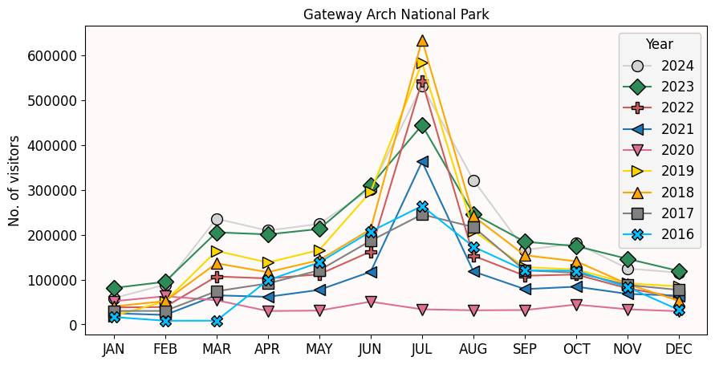

```python
# Just press Shift + Enter to run this cell
# Or click on the "Play/Run" button on the top menu

# Set up plot details

font_size = 12
color_list = ['lightgray', 'seagreen', 'indianred', 'tab:blue', 'palevioletred', 'gold', 'orange', 'gray', 'deepskyblue']
marker_list = ['o', 'D', 'P', '<', 'v', '>', '^', 's', 'X', 'h']
xaxis = list(range(visits.shape[1]))

# Making the plot pretty
fig, ax = plt.subplots(1, 1, figsize=(10,5), sharex=True)
ax.set_ylabel('No. of visitors', fontsize=font_size)
ax.set_title('Gateway Arch National Park', fontsize=font_size)
ax.set_facecolor('snow')
ax.tick_params(labelsize=font_size)
ax.set_xticks(xaxis, visits.columns)

# The actual data is plotted
for i in range(len(visits)):
    ax.plot(xaxis, visits.iloc[i], color=color_list[i], marker=marker_list[i], mec='k', ms=10, label=visits.index[i])
ax.legend(loc='upper right', fontsize=font_size, title='Year', title_fontsize='large', framealpha=1, facecolor='whitesmoke');
```

✅ **Task 5: Data interpretation II**

- What is the month with the most visitors? Do you find it surprising or does it check out your intuition/experience? Explain.
- How big is the gap between the most visited month vs the second most visited month?
- Do all years follow the same trend? Is there a year that looks very different than the rest? If so, do you find it surprising or does it check out your intuition/experience? Explain.
- Say you and your family want to visit the Gateway Arch National Park. Assuming that everybody can take time off anytime, what month would you suggest to go?

(Click on this cell and then press `Enter` to edit it)

✎ *From the graph I above I see that..*

✅ **Task 6: Compare and contrast**

Compare your experience between **Task 4** and **Task 5**.

- Which Task did you find easier?
- Was there something that you noticed from the plot that you would have missed just looking at numbers?

(Click on this cell and then press `Enter` to edit it)

✎ *Your answer*

### Assignment wrap-up

Please fill out form from the link below. You must log-in using your MU credentials. **You must completely fill this out in order to receive credit for the assignment!**

#### https://forms.office.com/r/cADesBUd7V

```python
# Click on the link above if this cell fails to produce a survey form.

from IPython.display import HTML
HTML(
"""
<iframe
	src="https://forms.office.com/r/cADesBUd7V"
	width="800px"
	height="600px"
	frameborder="0"
	marginheight="0"
	marginwidth="0">
	Click the link above if this cell fails to produce a survey
</iframe>
"""
)
```

[interactive chart not shown]

## Congratulations, you're done!

Save this notebook by going to the "File" tab on the top of the notebook and click "Save Notebook as". Alternatively, press `Ctrl` + `Shift` + `S`. Make sure to change "STUDENT" for your last name in the filename.

Submit this assignment by uploading it to the course Canvas web page. Go to the "In-class assignments" folder, find the assignment submission link for Day 1, and upload it there. Make sure you feel comfortable navigating within Jupyter.

### Is there still time?

Feel free to start digging into the Pre-Class assignment for the next session. You will find it in the Canvas webpage.

See you next class!

© Copyright 2026, Division of Plant Science & Technology—University of Missouri